# Prosper loan data exploration:

## - Dhriti Nirmal

### Preliminary wrangling

This data set contains information on peer to peer loans facilitated by credit company Prosper. This document explores a dataset containing 113,937 loans with 81 variables on each loan, including loan amount, borrower rate (or interest rate), current loan status, borrower income, and many others.

|  | ListingKey | ListingNumber | ListingCreationDate | CreditGrade | Term | LoanStatus | ClosedDate | BorrowerAPR | BorrowerRate | LenderYield | ... | LP_ServiceFees | LP_CollectionFees | LP_GrossPrincipalLoss | LP_NetPrincipalLoss | LP_NonPrincipalRecoverypayments | PercentFunded | Recommendations | InvestmentFromFriendsCount | InvestmentFromFriendsAmount | Investors |
| --- | --- | --- | --- | --- | --- | --- | --- | --- | --- | --- | --- | --- | --- | --- | --- | --- | --- | --- | --- | --- | --- |
| 0 | 1021339766868145413AB3B | 193129 | 2007-08-26 19:09:29.263000000 | C | 36 | Completed | 2009-08-14 00:00:00 | 0.16516 | 0.1580 | 0.1380 | ... | -133.18 | 0.0 | 0.0 | 0.0 | 0.0 | 1.0 | 0 | 0 | 0.0 | 258 |
| 1 | 10273602499503308B223C1 | 1209647 | 2014-02-27 08:28:07.900000000 | NaN | 36 | Current | NaN | 0.12016 | 0.0920 | 0.0820 | ... | 0.00 | 0.0 | 0.0 | 0.0 | 0.0 | 1.0 | 0 | 0 | 0.0 | 1 |
| 2 | 0EE9337825851032864889A | 81716 | 2007-01-05 15:00:47.090000000 | HR | 36 | Completed | 2009-12-17 00:00:00 | 0.28269 | 0.2750 | 0.2400 | ... | -24.20 | 0.0 | 0.0 | 0.0 | 0.0 | 1.0 | 0 | 0 | 0.0 | 41 |
| 3 | 0EF5356002482715299901A | 658116 | 2012-10-22 11:02:35.010000000 | NaN | 36 | Current | NaN | 0.12528 | 0.0974 | 0.0874 | ... | -108.01 | 0.0 | 0.0 | 0.0 | 0.0 | 1.0 | 0 | 0 | 0.0 | 158 |
| 4 | 0F023589499656230C5E3E2 | 909464 | 2013-09-14 18:38:39.097000000 | NaN | 36 | Current | NaN | 0.24614 | 0.2085 | 0.1985 | ... | -60.27 | 0.0 | 0.0 | 0.0 | 0.0 | 1.0 | 0 | 0 | 0.0 | 20 |

5 rows × 81 columns

|  | index | LoanOriginalAmount | LoanStatus | BorrowerAPR | StatedMonthlyIncome | Term | ProsperRating (Alpha) | EmploymentStatus | Occupation | BorrowerRate |
| --- | --- | --- | --- | --- | --- | --- | --- | --- | --- | --- |
| 0 | 1 | 10000 | Current | 0.12016 | 6125.000000 | 36 | A | Employed | Professional | 0.0920 |
| 1 | 3 | 10000 | Current | 0.12528 | 2875.000000 | 36 | A | Employed | Skilled Labor | 0.0974 |
| 2 | 4 | 15000 | Current | 0.24614 | 9583.333333 | 36 | D | Employed | Executive | 0.2085 |
| 3 | 5 | 15000 | Current | 0.15425 | 8333.333333 | 60 | B | Employed | Professional | 0.1314 |
| 4 | 6 | 3000 | Current | 0.31032 | 2083.333333 | 36 | E | Employed | Sales - Retail | 0.2712 |

### What is the structure of your dataset?

The dataset contains 113,937 loans with 81 features (including LoanOriginalAmount, BorrowerAPR, StatedMonthlyIncome, Term, ProsperRating (Alpha), EmploymentStatus and many others)

### What is the main feature of your dataset?

My main feature of interest is BorrowerAPR (The Borrower's annual percentage rate) and which factors affect this and predict this.

### What features in the dataset do you think will help support your investigation into your feature(s) of interest?

I am assuming the original loan amount, Stated monthly income and their employment status will affect the APR. Rest I will find out ahead and draw my conclusions.

## Univariate Exploration:

Distribution of the main variable of interest: borrower APR.

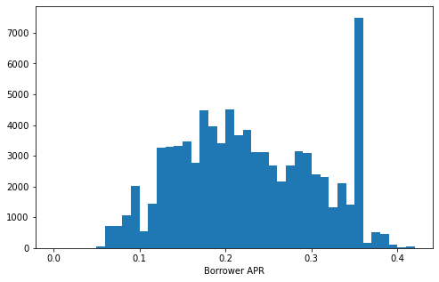

This distribution is interesting, there is a small peak just before 0.1, two large peaks around 0.2. There is also a small peak centered 0.3. We also notice there are very few loans have APR greater than 0.4.

### Discuss the distribution(s) of your variable(s) of interest. Were there any unusual points? Did you need to perform any transformations?

1. The distribution of borrowers APR looks multimodal.
2. Most of the values are at the range of 0.05 and 0.4.

### Bivariate Exploration:

I'll try to plot a scatterplot using seaborn. scatterplot between BorrowerAPR and LoanOriginalAmount:

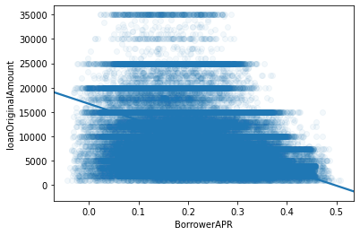

The scatter plot here shows a negative correlation between BorrowerAPR and LoanOriginalAmount which can imply to one thing, that is, the more the loan amount, the lower the APR.

I'll plot a boxplot between Term and BorrowerAPR:

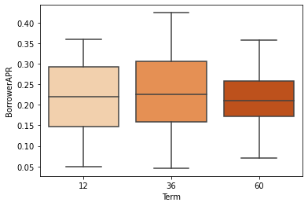

I notice that when the length of the loan in months is 36, the APR is the most and when the Term is 60, the APR is the least.

I'll plot a boxplot between EmploymentStatus and BorrowerAPR:

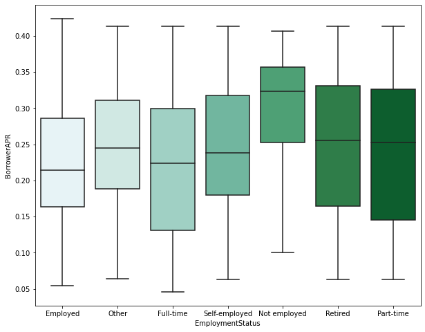

I see that unemployed borrowers have greater APR and the employed borrowers have the least APR.

I'll plot a boxplot between ProsperRating and BorrowerAPR:

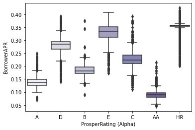

I notice that the borrowers with the best Prosper ratings have the least APR.

### Talk about some of the relationships you observed in this part of the investigation. How did the feature(s) of interest vary with other features in the dataset?

1. The borrower APR is negatively correlated with the loan original amount, which mean the more the loan amount, the lower the APR.
2. It also shows that at different size of the loan amount, the APR has a large range, but the range of APR decrease with the increase of loan amount.
3. The Prosper rating also affects on the borrower APR, which decreases with the better rating.
4. Unemployed borrowers have greater APR and the employed borrowers have the least APR.
5. I notice that when the length of the loan in months is 36, the APR is the most and when the Term is 60, the APR is the least.

## Multivariate Exploration:

I want to examine how the ProsperRating(Alpha) affects the relation between LoanOriginalAmount and BorrowerAPR:

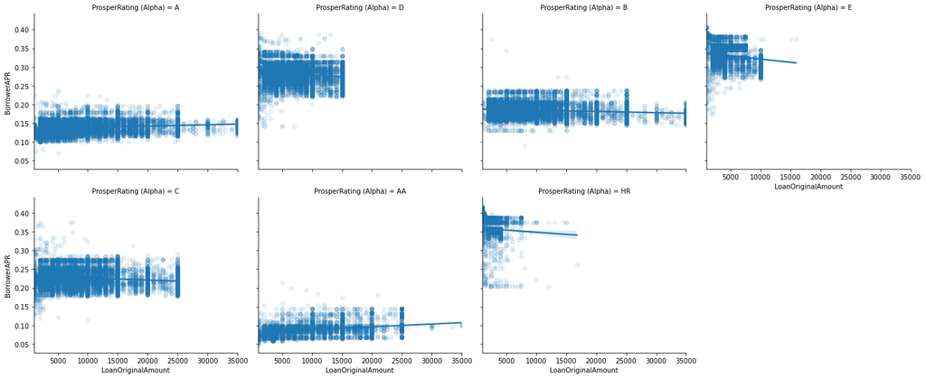

1. The loan amount increases with better rating.
2. The borrower APR decreases with better rating.
3. Interestingly, the relationship between borrower APR and loan amount turns from negative to slightly positive when the Prosper ratings are increased from HR to A or better. This was expected as the bivariate explorations showed similar relations between the variables.

I want to explore in this part of the analysis is how term affects the relationship between borrower APR and loan original amount:

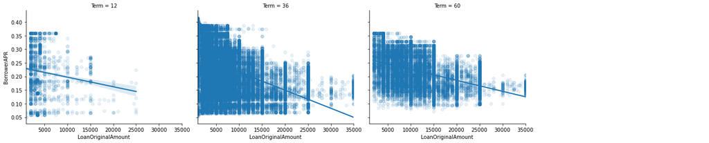

As I can see here, term doesnt really affects the relation between BorrowerAPR and loanoriginalamount, which remains negatively correlated throughout all the terms.

### Talk about some of the relationships you observed in this part of the investigation. Were there features that strengthened each other in terms of looking at your feature(s) of interest?

1. term doesnt really affects the relation between BorrowerAPR and loanoriginalamount, which remains negatively correlated throughout all the terms.
2. The loan amount increases with better rating.
3. The borrower APR decreases with better rating.
4. Interestingly, the relationship between borrower APR and loan amount turns from negative to slightly positive when the Prosper ratings are increased from HR to A or better.